# 1 Packages and Loading Data

#### Numpy and Pandas for data manipulation, pyplot and cm for exploratory analysis charts.

```python
import pandas as pd
import numpy as np
import matplotlib.pyplot as plt
from matplotlib import cm
```

#### Loading and checking out the data.

```python
data = pd.read_csv("survey.csv")
data.head()
```

|  | answer_id | course_id | student_id | survey_id | question_id | question_category | answer_content | course_day | answer_datetime |
| --- | --- | --- | --- | --- | --- | --- | --- | --- | --- |
| 0 | 1450682 | 4 | 12070 | 3142 | 7127 | NPS | 10 | 1 | 2021-04-10 18:00:02 |
| 1 | 1450685 | 4 | 12070 | 3142 | 4198 | commentary | Foi um ótimo curso, mas poderia ter um pouco m... | 1 | 2021-04-10 18:00:02 |
| 2 | 1450703 | 4 | 12492 | 3142 | 7127 | NPS | 10 | 1 | 2021-04-10 18:01:28 |
| 3 | 1450717 | 4 | 12492 | 3142 | 4198 | commentary | Bom material, bons professores, bom tudo | 1 | 2021-04-10 18:01:28 |
| 4 | 1450722 | 4 | 12229 | 3142 | 7127 | NPS | 9 | 1 | 2021-04-10 18:02:55 |

```python
data.shape
```

```
(535, 9)
```

## 1.1 Data Cleanup

#### Removing not found question values.

```python
data_notna = data[data['question_category'].notna()]
data_notna.head(10)
```

|  | answer_id | course_id | student_id | survey_id | question_id | question_category | answer_content | course_day | answer_datetime |
| --- | --- | --- | --- | --- | --- | --- | --- | --- | --- |
| 0 | 1450682 | 4 | 12070 | 3142 | 7127 | NPS | 10 | 1 | 2021-04-10 18:00:02 |
| 1 | 1450685 | 4 | 12070 | 3142 | 4198 | commentary | Foi um ótimo curso, mas poderia ter um pouco m... | 1 | 2021-04-10 18:00:02 |
| 2 | 1450703 | 4 | 12492 | 3142 | 7127 | NPS | 10 | 1 | 2021-04-10 18:01:28 |
| 3 | 1450717 | 4 | 12492 | 3142 | 4198 | commentary | Bom material, bons professores, bom tudo | 1 | 2021-04-10 18:01:28 |
| 4 | 1450722 | 4 | 12229 | 3142 | 7127 | NPS | 9 | 1 | 2021-04-10 18:02:55 |
| 5 | 1450724 | 4 | 12229 | 3142 | 4198 | commentary | Gostei muito, queria saber se tem como falar c... | 1 | 2021-04-10 18:02:55 |
| 6 | 1450742 | 4 | 12278 | 3142 | 7127 | NPS | 6 | 1 | 2021-04-10 18:04:21 |
| 8 | 1450757 | 4 | 12278 | 3142 | 4198 | commentary | Falta melhorar os exercícios práticos, o profe... | 1 | 2021-04-10 18:04:21 |
| 9 | 1450758 | 4 | 12297 | 3142 | 7127 | NPS | 10 | 1 | 2021-04-10 18:05:48 |
| 10 | 1450765 | 4 | 12297 | 3142 | 4198 | commentary | Aqui tem um link legal de um material que pode... | 1 | 2021-04-10 18:05:48 |

#### Checking how many rows were left.

```python
data_notna.shape
```

```
(530, 9)
```

#### Dropping non necessary columns.

```python
data_relevant = data_notna.drop(['answer_id','course_id','survey_id','answer_datetime'], axis = 1)
data_relevant.head()
```

|  | student_id | question_id | question_category | answer_content | course_day |
| --- | --- | --- | --- | --- | --- |
| 0 | 12070 | 7127 | NPS | 10 | 1 |
| 1 | 12070 | 4198 | commentary | Foi um ótimo curso, mas poderia ter um pouco m... | 1 |
| 2 | 12492 | 7127 | NPS | 10 | 1 |
| 3 | 12492 | 4198 | commentary | Bom material, bons professores, bom tudo | 1 |
| 4 | 12229 | 7127 | NPS | 9 | 1 |

# 2 Exploratory Analysis

#### Building a pivot table for each one of the course_day values, showing each student's survey answers grouped in a row.

```python
data_pivot = []
for n in range(0,len(data_relevant[data_relevant.course_day != 0].course_day.unique())):
    data_pivot.append(data_relevant[data_relevant.course_day == n+1].pivot(index = 'student_id', columns = 'question_category', values = 'answer_content'))
    data_pivot[n].NPS = data_pivot[n].NPS.astype(int)
    data_pivot[n].commentary.astype(str)

# Checking one of the outputs
data_pivot[0].head()
data_pivot[0]
```

| question_category student_id | NPS | commentary |
| --- | --- | --- |
| 10442 | 8 | video aulas sensacionais |
| 11292 | 10 | assim que tiver mais horas no curso eu falo |
| 11449 | 8 | ainda nao consigo opinar direito |
| 11722 | 9 | - |
| 11724 | 10 | valeu muito a pena o investimento, estou adorando |
| ... | ... | ... |
| 19924 | 10 | fiz um exercicio e nao entendi a resolucao dep... |
| 19929 | 7 | Professor não deve ter dado aula nunca, não te... |
| 19944 | 10 | o dia foi muito bom, e os alunos estao se ajud... |
| 19977 | 10 | tive que pesquisar uma coisa das video aulas, ... |
| 19984 | 10 | falta exercício prático mais claro e feedback ... |

111 rows × 2 columns

#### Total answers in each course_day

```python
for n in range(0,len(data_relevant[data_relevant.course_day != 0].course_day.unique())):
    print(f'Total anwswers in day {n}: {data_pivot[n].shape[0]}')
```

```
Total anwswers in day 0: 111
Total anwswers in day 1: 97
Total anwswers in day 2: 57
```

#### Measuring the NPS (Net Promoter Score) in each course_day

```python
def nps(answers):
    nps_grade = 0
    for grade in answers:
        if grade >= 9:
            nps_grade += 1
        elif grade <= 6:
            nps_grade -= 1
    return round(nps_grade/len(answers)*100,2)

for n in range(0,len(data_relevant[data_relevant.course_day != 0].course_day.unique())):
    x = data_pivot[n]['NPS']
    print(f'Day {n+1} NPS was {nps(x.values)}')
```

```
Day 1 NPS was 76.58
Day 2 NPS was 59.79
Day 3 NPS was 36.84
```

#### Drawing a chart for each course_day showing the value counts for each grade.

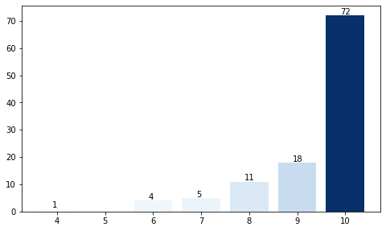

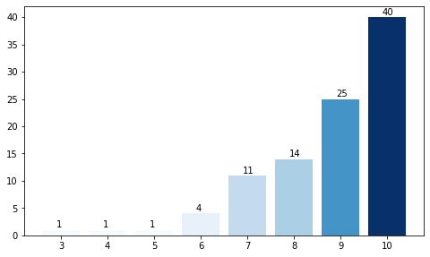

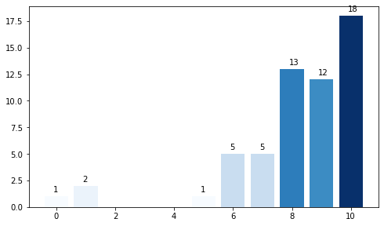

```python
my_cmap = plt.get_cmap("Blues")
for n in range(0,len(data_relevant[data_relevant.course_day != 0].course_day.unique())):
    plt.figure(figsize = (8,16))
    plt.subplot(len(data_relevant[data_relevant.course_day != 0].course_day.unique()),1,n+1)
    grNps = data_pivot[n]['NPS'].value_counts().sort_index(ascending = False)
    rescale = lambda y: (y - np.min(y)) / (np.max(y) - np.min(y))
    bars = plt.bar(x = grNps.index, height = grNps.values, color=my_cmap(rescale(grNps.values)))
    for bar in bars:
        yval = bar.get_height()
        plt.text(bar.get_x()+0.3, yval + 0.4, yval)
    plt.show()
```

#### Plotting the value counts of each day side-by-side.

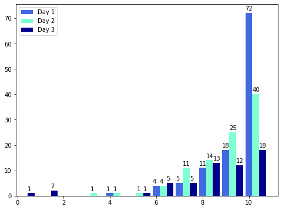

```python
fig = plt.figure(figsize = (8,6))
colors = ['royalblue','aquamarine','darkblue']
for n in range(0,len(data_relevant[data_relevant.course_day != 0].course_day.unique())):
    grNps = data_pivot[n]['NPS'].value_counts().sort_index(ascending = False)
    bars = plt.bar(x = grNps.index+n*0.3, height = grNps.values, width = 0.3, color=colors[n], label = str(f'Day {n+1}'))
    for bar in bars:
        yval = bar.get_height()
        plt.text(bar.get_x(), yval + 1.0, yval)
plt.legend(loc= 'upper left')
plt.show()
```

# 3 NLP (natural language processing)

The way humans talk is not something comprehensible to a computer. Therefore, before applying computer-based algorithms, groupings, charts, etc. we need to convert data to a more "understandable", or "machine-friendly", form so that we get to process and analyze such data. This is where NLP comes in, combining linguistics with computer science, to transform words and sentences that we so commonly use in their infinite forms, to more neutral and common words, e.g. changing "eating" and "ate" to simply "eat".

#### Importing some packages for NLP and text manipulation (and installing them if need be)

```python
#!pip install spacy
#!pip install nltk
```

```python
import re
#import nltk
import spacy
import string
from nltk.corpus import stopwords
from nltk.tokenize import word_tokenize
from nltk.collocations import BigramCollocationFinder
from nltk.collocations import TrigramCollocationFinder
```

#### Downloading nltk's resources.

```python
# import nltk
# nltk.download('punkt')
# nltk.download('stopwords')
```

## Subsetting Data

#### We can now choose which subset of data we want to analyze. We have three options:

1. All Data
2. Single Course Day Data
3. Only Detractors Data (people who grade the course 6 or lower in the survey)

#### The following three snippets of code contain each subset, and the one left uncommented will be the one used in the rest of the script.

```python
# # All Data
# data_pln = data_relevant[data_relevant.question_category == 'commentary']['answer_content'].astype(str)
```

```python
# # Single course day data (change the data_relevant.course_day == x portion to the day number to analyze)
data_pln = data_relevant[data_relevant.question_category == 'commentary'][data_relevant.course_day == 2]['answer_content'].astype(str)
```

```python
# # Detractors data
# data_detractors = data_relevant.pivot(index = ['student_id','course_day'], columns = 'question_category', values = 'answer_content')
# data_detractors = data_detractors.reset_index()
# data_pln = data_detractors[data_detractors.NPS.astype(int) <= 6]['commentary'].astype(str)
```

#### Chosen data:

```python
print("Rows remaining in dataset: "+str(data_pln.shape[0])+"\n")
print(data_pln)
```

```
Rows remaining in dataset: 97

226    Adorei o professor, e a turma estava bem engajada
228    Tive que pesquisar uma coisa que não tinha, ma...
231    Gostei muito da didática do professor, e as au...
233                                                    -
235    não gostei tanto do dia, achei que faltou orga...
                             ...
411                                   tudo bem ate agora
413    o professor não sabe ensinar direito e as vide...
415    gostei muito do dia de curso, as pessoas estão...
417                                                    -
419                                                   ok
Name: answer_content, Length: 97, dtype: object
```

## 3.1 Stopwords

Stopwords are defined as words that do not add any meaning to our sentences, such as the "as" in this sentece. It is common in NLP pipelines to remove such words before any processing. For this project, I'll be using NLTK's stopwords list.

#### Creating a nltk's stopwords list (data is pt-br so using portuguese stopwords)

```python
pt_stopwords = set(stopwords.words('portuguese'))
#pt_stopwords
```

#### Function to tokenize sentences and remove the stopwords.

```python
def remove_stopwords(sentence):
    word_tokens = word_tokenize(sentence)

    filtered_sentence = [w for w in word_tokens if not w.lower() in pt_stopwords]

    filtered_sentence = []

    for w in word_tokens:
        if w not in pt_stopwords:
            filtered_sentence.append(w)

    return filtered_sentence
```

#### Applying the function to our data and showing the output.

```python
data_pln_stopwords = data_pln.apply(remove_stopwords)
```

```python
data_pln_stopwords.head(5)
```

```
226         [Adorei, professor, ,, turma, bem, engajada]
228            [Tive, pesquisar, coisa, ,, resto, ótimo]
231        [Gostei, didática, professor, ,, aulas, boas]
233                                                  [-]
235    [gostei, tanto, dia, ,, achei, faltou, organiz...
Name: answer_content, dtype: object
```

## 3.2 Removing punctuation and applying Lemmatisation

Depending on the processing used, we should our shouldn't remove punctuation. In this case, where I'm going to simply analyze words and word combinations, there is no need for punctuation so we are taking it out.

Lemmatisation, in linguistics, is a manner of extracting more "common" forms of words, grouping inflected words into a single item, called lemma. This way, we can group together words such as "ate" and "eating" under the single form "eat", as this item defines its' meaning.

#### Importing the necessary SpaCy portuguese pipeline (and downloading it, if needed)

```python
#!spacy download pt_core_news_sm
```

```python
import pt_core_news_sm
nlp = pt_core_news_sm.load()
```

#### Function to clean text by using regex (regular expressions) to remove punctuation and using Spacy to apply lemmatisation.

```python
def clean_sentences(text):

    # Removes pontuação using regular expressions
    regex = re.compile('[' + re.escape(string.punctuation) + '\\r\\t\\n]')
    nopunct = regex.sub("", str(text))

    # Using SpaCy for lemmatisation
    doc = nlp(nopunct, disable = ['parser', 'ner'])
    lemma = [token.lemma_ for token in doc]
    return lemma
```

#### Applying function to the data.

```python
data_pln_lematized = data_pln_stopwords.map(clean_sentences)
data_pln_lematized.head()
```

```
226          [Adorei, professor,  , turma, bem, engajar]
228           [Tive, pesquisar, coisa,  , restar, ótimo]
231          [Gostei, didática, professor,  , aula, bom]
233                                                   []
235    [gostar, tanto, dia,  , achar, faltar, organiz...
Name: answer_content, dtype: object
```

#### Changing all words to lower case

```python
data_pln_lower = data_pln_lematized.map(lambda x: [word.lower() for word in x])
data_pln_lower.head()
```

```
226          [adorei, professor,  , turma, bem, engajar]
228           [tive, pesquisar, coisa,  , restar, ótimo]
231          [gostei, didática, professor,  , aula, bom]
233                                                   []
235    [gostar, tanto, dia,  , achar, faltar, organiz...
Name: answer_content, dtype: object
```

#### Creating a comparison between the original sentences and the processed data.

```python
pd.DataFrame(data_pln).reset_index().merge(pd.DataFrame(data_pln_lower).reset_index(),'inner', 'index')\
.rename(columns={'commentary_x': 'original_answer', 'commentary_y': 'processed_answer'}).head(10)
```

|  | index | answer_content_x | answer_content_y |
| --- | --- | --- | --- |
| 0 | 226 | Adorei o professor, e a turma estava bem engajada | [adorei, professor, , turma, bem, engajar] |
| 1 | 228 | Tive que pesquisar uma coisa que não tinha, ma... | [tive, pesquisar, coisa, , restar, ótimo] |
| 2 | 231 | Gostei muito da didática do professor, e as au... | [gostei, didática, professor, , aula, bom] |
| 3 | 233 | - | [] |
| 4 | 235 | não gostei tanto do dia, achei que faltou orga... | [gostar, tanto, dia, , achar, faltar, organiz... |
| 5 | 237 | muito bom o material online | [bom, material, online] |
| 6 | 239 | a plataforma é muito boa e as video aulas melh... | [plataforma, bom, video, aula, melhorar, ainda] |
| 7 | 241 | o dia de curso poderia ter mais atividades | [dia, cursar, poder, ter, atividades] |
| 8 | 243 | ate agora tudo ok | [atar, agora, tudo, ok] |
| 9 | 245 | achei o conteúdo péssimo e faltou mais materia... | [achar, conteúdo, mau, faltar, material, expli... |

## 3.3 Tokenization e removing outlier words

#### Tokenization, in lexical analysis, is the process of classifying a set of characters, segmenting them in such way that it would make sense for a natural language speaker. It could mean transforming an entire book in a set of chapters, or a paragraph in a set of phrases, depending on the process that will be used further down the NLP pipeline. In this case, we will simply split each phrase in a set of words.

```python
answers_tokens = [item for items in data_pln_lower for item in items]
#answers_tokens
```

#### Some of our resulting words have unusual lenghts, since in the survey's answers people could insert links. As such, we'll remove any words above a set character length to avoid such invalid data. Some words got split into meaningless empty spaces, so we'll take care of that as well.

```python
answers_notnull = pd.Series(answers_tokens)[pd.Series(answers_tokens).apply(lambda x: len(x)) > 2]
#answers_notnull
```

```python
answers_final = answers_notnull[answers_notnull.apply(lambda x: len(x)) <= 16]
#answers_final
```

```python
pd.DataFrame(answers_final).head(10)
```

|  | 0 |
| --- | --- |
| 0 | adorei |
| 1 | professor |
| 3 | turma |
| 4 | bem |
| 5 | engajar |
| 6 | tive |
| 7 | pesquisar |
| 8 | coisa |
| 10 | restar |
| 11 | ótimo |

## 3.4 Most Used Words

```python
pd.DataFrame(answers_final).value_counts().head(30)
```

```
bom           25
aula          23
dia           17
professor     13
ainda         11
cursar        11
bem           10
video         10
poder         10
pra            9
algum          9
plataforma     9
coisa          8
ter            8
achar          8
teoria         6
online         6
ensinar        5
melhorar       5
nado           5
suportar       5
gostar         4
tempo          4
bastante       4
sentir         4
querer         4
saber          4
pouco          4
muito          4
ajudar         4
dtype: int64
```

## 3.5 Bigrams

#### Bigrams, or more specifically a n-gram of n=2, is a form of statistical analysis of text that takes combinations of adjacent elements from a text, in our case words. This way we can visualize the most used two-word combinations from our data, giving some insight into the users' opinion.

#### Creating a Bigram finder from NLTK's package with our tokenized data

```python
findBigrams = BigramCollocationFinder.from_words(answers_final.values)
```

#### Counting bigrams in the tokenized data

```python
bigram_freq = findBigrams.ngram_fd.items()
# bigram_freq
```

#### Making a Pandas DataFrame with the bigrams' frequency list

```python
FreqTabBigramas = pd.DataFrame(list(bigram_freq),
                               columns = ['Bigrama', 'Freq']).sort_values(by = 'Freq', ascending = False)
FreqTabBigramas.head(10)
```

|  | Bigrama | Freq |
| --- | --- | --- |
| 29 | (video, aula) | 8 |
| 33 | (dia, cursar) | 8 |
| 35 | (poder, ter) | 6 |
| 22 | (cursar, bom) | 5 |
| 13 | (aula, bom) | 4 |
| 147 | (aula, online) | 4 |
| 101 | (poder, melhorar) | 3 |
| 57 | (professor, dia) | 3 |
| 183 | (professor, saber) | 2 |
| 30 | (aula, melhorar) | 2 |

## 3.6 Trigrams

#### Repeating the same process for trigrams, n-grams with n=3, obtaining the most used three-word combinations.

#### Counting trigrams in the tokenized data

```python
findTrigrams = TrigramCollocationFinder.from_words(answers_final.values)
```

#### Making a Pandas DataFrame with the trigrams' frequency list

```python
trigram_freq = findTrigrams.ngram_fd.items()
#trigram_freq
```

```python
# Tabela de frequência no formato do Pandas para os trigramas
FreqTabTrigramas = pd.DataFrame(list(trigram_freq),
                                columns = ['Trigrama','Freq']).sort_values(by = 'Freq', ascending = False)
```

```python
# Visualiza a tabela
FreqTabTrigramas.head(10)
```

|  | Trigrama | Freq |
| --- | --- | --- |
| 59 | (dia, cursar, bom) | 3 |
| 196 | (professor, saber, ensinar) | 2 |
| 29 | (video, aula, melhorar) | 2 |
| 58 | (professor, dia, cursar) | 2 |
| 28 | (bom, video, aula) | 2 |
| 0 | (adorei, professor, turma) | 1 |
| 324 | (puxar, pouco, dificil) | 1 |
| 320 | (tempo, pra, estudar) | 1 |
| 321 | (pra, estudar, pouco) | 1 |
| 322 | (estudar, pouco, puxar) | 1 |

# 4 Wordclouds

#### Wordcloud are a form of displaying text data that has been commonly used by the media recently, for its easy readability. As a result of the project, three wordclouds will be created, to show the most used words, bigrams and tri-grams, giving insight to commonly expressed opinions by users in the survey's data.

#### Importing (and installing if necessary) the wordcloud package

```python
#!pip install wordcloud
# Should pip not work, and you're using Anaconda, try this in Anaconda Prompt instead:
#conda install -c https://conda.anaconda.org/conda-forge wordcloud
```

```python
from wordcloud import WordCloud
```

#### Generating the wordcloud base object, with no data.

```python
wordcloud = WordCloud(background_color="white",width=1600, height=800)
```

## 4.1 Unique words

#### Converting the final dataset to the wordcloud package expected input, a full string of text.

```python
text = " ".join(str(word) for word in answers_final)
```

#### Generating the unique words wordcloud.

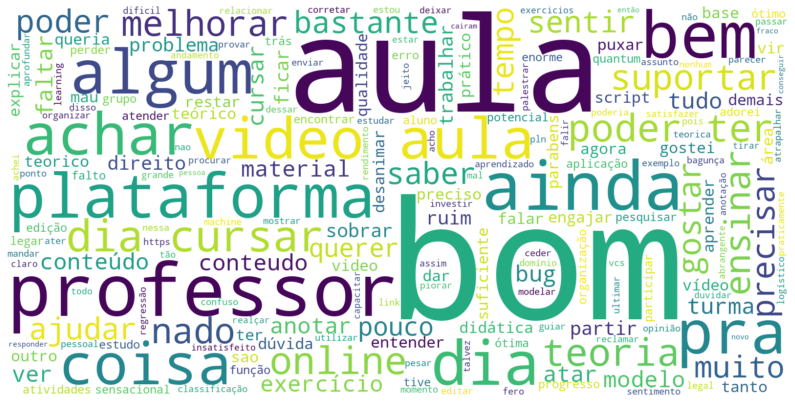

```python
wordcloud.generate(text)
plt.figure(figsize = (14,10))
plt.imshow(wordcloud, interpolation='bilinear')
plt.axis("off")
plt.show()
```

## 4.2 Bigrams

#### Applying a function to obtaing the same text input that wordcloud expects, but to our bigram data from the bigram frequency table.

```python
join_words = pd.Series(bigram_freq).apply(lambda x:[x[0][0]+"_"+x[0][1],x[1]])
freq_dict = {}
for a, x in join_words:
    freq_dict[a] = x
```

#### Generating the bigrams' wordcloud.

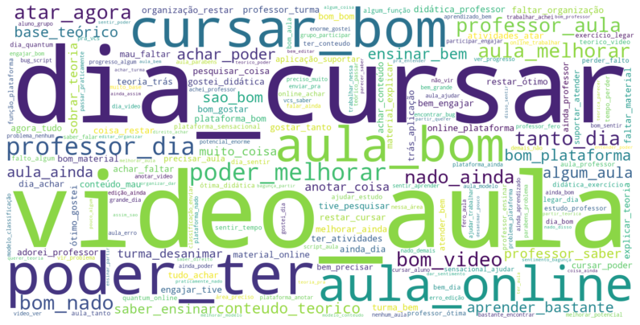

```python
wordcloud.generate_from_frequencies(freq_dict)
plt.figure(figsize = (14,10))
plt.imshow(wordcloud, interpolation='bilinear')
plt.axis("off")
plt.show()
```

## 4.3 Trigrams

```python
join_words = pd.Series(trigram_freq).apply(lambda x:[x[0][0]+"_"+x[0][1]+"_"+x[0][2],x[1]])
freq_dict = {}
for a, x in join_words:
    freq_dict[a] = x
```

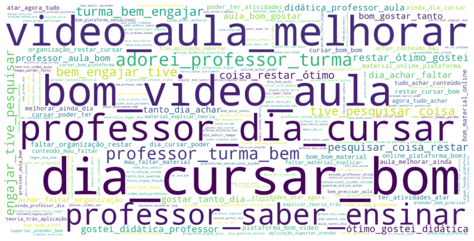

```python
wordcloud.generate_from_frequencies(freq_dict)
plt.figure(figsize = (14,10))
plt.imshow(wordcloud, interpolation='bilinear')
plt.axis("off")
plt.show()
```

### Therefore, we could conclude, looking at the wordclouds, that something is up with our online video classes, seeing as 'video aula' and 'video_aula_melhorar', which mean 'improve video classes', appeared with certain frequency in all wordclouds. Also, the live classes and the teacher received some praise, because 'professor_saber_ensinar', which would somewhat translate to 'professor good at teaching', was one of the most frequent trigrams.

### We could keep analyzing other subsets of data for more insights and even extract more data from other courses, but seeing as this is a simple demonstration, it should be enough for planning the next steps of our ficticious company. ;)